# House Price Model

### The Data is collected from https://fred.stlouisfed.org/ and formatted accordingly for last 20 years

```python
import numpy as np
import pandas as pd
from datetime import datetime
import seaborn as sns
import matplotlib.pyplot as plt
%matplotlib inline
```

```python
df = pd.read_csv(r'C:\Users\Asus\Downloads\Factors Data Fred.csv')
df
```

|  | DATE | GNP | GDP | CORESTICKM159SFRBATL | DPRIME | DFF | UNRATE | LREM64TTUSM156S | CNP16OV | PAYEMS | MDSP | DSPI | H8B1026NCBCMG | CSUSHPISA |
| --- | --- | --- | --- | --- | --- | --- | --- | --- | --- | --- | --- | --- | --- | --- |
| 0 | 01-01-1987 | 4872.70375 | 4855.21625 | 4.319637529 | 8.203373016 | 6.660356 | 6.175 | 70.74526842 | 182752.75 | 102114.4167 | 5.762797 | 3472.016667 | 17.191667 | 66.251 |
| 1 | 01-01-1988 | 5259.095 | 5236.438 | 4.586414374 | 9.318 | 7.571803 | 5.491666667 | 71.64973476 | 184612.5833 | 105375.3333 | 5.7548325 | 3777.466667 | 12.575000 | 71.13416667 |
| 2 | 01-01-1989 | 5666.36875 | 5641.5795 | 4.78070343 | 10.872 | 9.214904 | 5.258333333 | 72.49765168 | 186392.6667 | 108046.8333 | 5.8859615 | 4057.85 | 13.975000 | 75.502 |
| 3 | 01-01-1990 | 5997.836 | 5963.1445 | 5.455351341 | 10.008 | 8.096521 | 5.616666667 | 72.18309317 | 189163.75 | 109527.8333 | 6.09006575 | 4319.116667 | 9.141667 | 76.93616667 |
| 4 | 01-01-1991 | 6189.716 | 6158.12925 | 4.949347124 | 8.462 | 5.685014 | 6.85 | 70.96115102 | 190924.8333 | 108433.8333 | 6.17497375 | 4496.008333 | 2.633333 | 75.92166667 |
| 5 | 01-01-1992 | 6551.4045 | 6520.32725 | 3.785416475 | 6.250996016 | 3.521066 | 7.491666667 | 70.80636179 | 192805.3333 | 108792.6667 | 5.88187575 | 4808.05 | 2.541667 | 76.32716667 |
| 6 | 01-01-1993 | 6889.71625 | 6858.5585 | 3.50752614 | 6 | 3.021342 | 6.908333333 | 71.2092656 | 194837.5833 | 110934.5833 | 5.696334 | 5009.175 | 4.816667 | 77.41241667 |
| 7 | 01-01-1994 | 7310.2025 | 7287.2365 | 3.272151669 | 7.144 | 4.206329 | 6.1 | 72.00669542 | 196814.5 | 114385.5833 | 5.553857 | 5254.025 | 6.941667 | 79.46658333 |
| 8 | 01-01-1995 | 7667.701 | 7639.74925 | 3.318259542 | 8.831 | 5.834301 | 5.591666667 | 72.53106275 | 198584.0833 | 117410.0833 | 5.6545855 | 5542.958333 | 7.941667 | 80.9905 |
| 9 | 01-01-1996 | 8103.991 | 8073.12175 | 3.09751488 | 8.271084337 | 5.300464 | 5.408333333 | 72.85988648 | 200590.5833 | 119819.3333 | 5.59514425 | 5841.425 | 6.200000 | 82.80616667 |
| 10 | 01-01-1997 | 8600.8525 | 8577.5525 | 2.757137044 | 8.443227092 | 5.461507 | 4.941666667 | 73.50704616 | 203133.25 | 122930.25 | 5.6077015 | 6160.65 | 7.991667 | 85.31408333 |
| 11 | 01-01-1998 | 9080.22775 | 9062.81675 | 2.611365655 | 8.355577689 | 5.350932 | 4.5 | 73.84508631 | 205220.0833 | 126136.75 | 5.48261825 | 6574.225 | 7.008333 | 90.09291667 |
| 12 | 01-01-1999 | 9662.0755 | 9631.17175 | 2.180331925 | 7.997047244 | 4.972356 | 4.216666667 | 73.94654908 | 207752.9167 | 129229.0833 | 5.53587375 | 6894.883333 | 8.333333 | 96.36533333 |
| 13 | 01-01-2000 | 10289.43225 | 10250.952 | 2.689386083 | 9.235119048 | 6.237432 | 3.966666667 | 74.09042387 | 212576.75 | 132018.3333 | 5.63823575 | 7419.575 | 11.608333 | 104.7684167 |
| 14 | 01-01-2001 | 10632.29275 | 10581.929 | 3.234150692 | 6.938 | 3.878356 | 4.741666667 | 73.11320142 | 215092.5 | 132078.25 | 5.78912 | 7773.758333 | 7.058333 | 113.1795 |
| 15 | 01-01-2002 | 10974.90175 | 10929.10825 | 3.235956558 | 4.67687747 | 1.666795 | 5.783333333 | 71.91501452 | 217569.5833 | 130634.5833 | 5.8067775 | 8108.766667 | 13.733333 | 122.2785 |
| 16 | 01-01-2003 | 11514.946 | 11456.4495 | 2.33001235 | 4.121541502 | 1.126493 | 5.991666667 | 71.21163271 | 221167.9167 | 130327 | 5.82796475 | 8494.983333 | 9.550000 | 133.731 |
| 17 | 01-01-2004 | 12293.90925 | 12217.19575 | 2.2195946 | 4.343873518 | 1.350328 | 5.541666667 | 71.2139371 | 223356.8333 | 131755.0833 | 5.89655475 | 8995.516667 | 13.458333 | 150.4400833 |
| 18 | 01-01-2005 | 13113.99725 | 13039.197 | 2.314240308 | 6.189243028 | 3.217068 | 5.083333333 | 71.52316375 | 226082.5833 | 134021.3333 | 6.3558355 | 9392.458333 | 13.791667 | 171.73675 |
| 19 | 01-01-2006 | 13862.043 | 13815.583 | 2.927103742 | 7.961155378 | 4.965425 | 4.608333333 | 71.98947212 | 228814.6667 | 136432.1667 | 6.75491775 | 10027.725 | 9.875000 | 183.4474167 |
| 20 | 01-01-2007 | 14569.89125 | 14474.227 | 2.7630326 | 8.053784861 | 5.017315 | 4.616666667 | 71.7723441 | 231867 | 137978.75 | 7.06674625 | 10528.875 | 6.308333 | 179.9188333 |
| 21 | 01-01-2008 | 14915.076 | 14769.8615 | 2.835870575 | 5.070866142 | 1.924180 | 5.8 | 70.8645372 | 233788 | 137224.9167 | 6.985938 | 10970.06667 | -0.850000 | 164.0571667 |
| 22 | 01-01-2009 | 14628.309 | 14478.06675 | 1.98720835 | 3.25 | 0.158603 | 9.283333333 | 67.60467916 | 235801 | 131290 | 6.70551225 | 10928.03333 | -6.066667 | 148.5445833 |
| 23 | 01-01-2010 | 15254.603 | 15048.97 | 0.839635428 | 3.25 | 0.176247 | 9.608333333 | 66.67215426 | 237829.3333 | 130334.5833 | 6.13639175 | 11356.88333 | -5.183333 | 144.6741667 |
| 24 | 01-01-2011 | 15837.66375 | 15599.73175 | 1.465280561 | 3.25 | 0.101507 | 8.933333333 | 66.62924045 | 239617.5 | 131919.5 | 5.58611625 | 11885.6 | -3.741667 | 139.26 |
| 25 | 01-01-2012 | 16486.72675 | 16253.97 | 2.170778667 | 3.25 | 0.140574 | 8.075 | 67.11954172 | 243284.3333 | 134154.3333 | 5.130189 | 12504.83333 | -0.816667 | 140.9946667 |
| 26 | 01-01-2013 | 17073.49325 | 16843.19575 | 1.944966442 | 3.25 | 0.107342 | 7.358333333 | 67.34606685 | 245679.3333 | 136358.3333 | 4.918647 | 12517.26667 | -0.725000 | 154.5204167 |
| 27 | 01-01-2014 | 17785.914 | 17550.68775 | 1.97728875 | 3.25 | 0.088493 | 6.158333333 | 68.14155808 | 247946.5833 | 138919.5 | 4.63433825 | 13191.99167 | 2.633333 | 164.6993333 |
| 28 | 01-01-2015 | 18426.407 | 18206.0235 | 2.167317292 | 3.259920635 | 0.133726 | 5.275 | 68.7010707 | 250800.5833 | 141801.1667 | 4.46955125 | 13745.275 | 6.583333 | 172.1824167 |
| 29 | 01-01-2016 | 18927.04975 | 18695.10575 | 2.565157442 | 3.510956175 | 0.393197 | 4.875 | 69.33675272 | 253537.5 | 144332.4167 | 4.40311625 | 14138.66667 | 5.941667 | 180.92725 |
| 30 | 01-01-2017 | 19770.28625 | 19477.3365 | 2.259383083 | 4.097222222 | 1.002959 | 4.358333333 | 70.10131169 | 255079 | 146610.9167 | 4.26398975 | 14791.225 | 3.775000 | 191.402 |
| 31 | 01-01-2018 | 20823.3645 | 20533.0575 | 2.419135667 | 4.902390438 | 1.834932 | 3.891666667 | 70.71672109 | 257790.6667 | 148897 | 4.16615375 | 15608.88333 | 3.225000 | 202.48475 |
| 32 | 01-01-2019 | 21659.02625 | 21380.976 | 2.527796083 | 5.287549407 | 2.157260 | 3.683333333 | 71.34893987 | 259175 | 150891.4167 | 4.10424425 | 16388.58333 | 3.458333 | 209.4734167 |
| 33 | 01-01-2020 | 21257.4445 | 21060.47425 | 2.22488825 | 3.530632411 | 0.372240 | 8.091666667 | 67.00868858 | 260329 | 142153.1667 | 3.86500175 | 17595.93333 | 0.425000 | 222.15525 |
| 34 | 01-01-2021 | 23488.1715 | 23315.08125 | 2.438006 | 3.25 | 0.078685 | 5.366666667 | 69.40252699 | 261445.1667 | 146280.9167 | 3.6917865 | 18633.11667 | 2.850000 | 260.0666667 |
| 35 | 01-01-2022 | 25640.1285 | 25462.72225 | 5.453909417 | 4.848605578 | 1.692192 | 3.641666667 | 71.26084138 | 263973.5 | 152625.25 | 3.931583 | 18580.56667 | 9.883333 | 298.4789167 |
| 36 | 01-01-2023 | . | . | . | . | 4.898054 | . | . | . | . | . | . | NaN | . |

```python
df.isnull().sum()
```

```
DATE                    0
GNP                     0
GDP                     0
CORESTICKM159SFRBATL    0
DPRIME                  0
DFF                     0
UNRATE                  0
LREM64TTUSM156S         0
CNP16OV                 0
PAYEMS                  0
MDSP                    0
DSPI                    0
H8B1026NCBCMG           1
CSUSHPISA               0
dtype: int64
```

```python
df.dropna(inplace = True)
```

```python
df.shape
```

```
(36, 14)
```

```python
df1 = df.copy()
```

```python
df1.describe()
```

|  | DFF | H8B1026NCBCMG |
| --- | --- | --- |
| count | 36.000000 | 36.000000 |
| mean | 3.131062 | 5.946296 |
| std | 2.683827 | 5.629407 |
| min | 0.078685 | -6.066667 |
| 25% | 0.387958 | 2.633333 |
| 50% | 2.589301 | 6.445833 |
| 75% | 5.313081 | 9.631250 |
| max | 9.214904 | 17.191667 |

```python
df1.info()
```

```
<class 'pandas.core.frame.DataFrame'>
Int64Index: 36 entries, 0 to 35
Data columns (total 14 columns):
 #   Column                Non-Null Count  Dtype
---  ------                --------------  -----
 0   DATE                  36 non-null     object
 1   GNP                   36 non-null     object
 2   GDP                   36 non-null     object
 3   CORESTICKM159SFRBATL  36 non-null     object
 4   DPRIME                36 non-null     object
 5   DFF                   36 non-null     float64
 6   UNRATE                36 non-null     object
 7   LREM64TTUSM156S       36 non-null     object
 8   CNP16OV               36 non-null     object
 9   PAYEMS                36 non-null     object
 10  MDSP                  36 non-null     object
 11  DSPI                  36 non-null     object
 12  H8B1026NCBCMG         36 non-null     float64
 13  CSUSHPISA             36 non-null     object
dtypes: float64(2), object(12)
memory usage: 4.2+ KB
```

```python
df1.columns
```

```
Index(['DATE', 'GNP', 'GDP', 'CORESTICKM159SFRBATL', 'DPRIME', 'DFF', 'UNRATE',
       'LREM64TTUSM156S', 'CNP16OV', 'PAYEMS', 'MDSP', 'DSPI', 'H8B1026NCBCMG',
       'CSUSHPISA'],
      dtype='object')
```

```python
df1[['GNP', 'GDP', 'CORESTICKM159SFRBATL', 'DPRIME', 'DFF', 'UNRATE',
       'LREM64TTUSM156S', 'CNP16OV', 'PAYEMS', 'MDSP', 'DSPI', 'H8B1026NCBCMG',
       'CSUSHPISA']] = df1[['GNP', 'GDP', 'CORESTICKM159SFRBATL', 'DPRIME', 'DFF', 'UNRATE',
       'LREM64TTUSM156S', 'CNP16OV', 'PAYEMS', 'MDSP', 'DSPI', 'H8B1026NCBCMG',
       'CSUSHPISA']].apply(pd.to_numeric)
```

```python
df1['DATE']= pd.to_datetime(df1['DATE'])
```

```python
df1.info()
```

```
<class 'pandas.core.frame.DataFrame'>
Int64Index: 36 entries, 0 to 35
Data columns (total 14 columns):
 #   Column                Non-Null Count  Dtype
---  ------                --------------  -----
 0   DATE                  36 non-null     datetime64[ns]
 1   GNP                   36 non-null     float64
 2   GDP                   36 non-null     float64
 3   CORESTICKM159SFRBATL  36 non-null     float64
 4   DPRIME                36 non-null     float64
 5   DFF                   36 non-null     float64
 6   UNRATE                36 non-null     float64
 7   LREM64TTUSM156S       36 non-null     float64
 8   CNP16OV               36 non-null     float64
 9   PAYEMS                36 non-null     float64
 10  MDSP                  36 non-null     float64
 11  DSPI                  36 non-null     float64
 12  H8B1026NCBCMG         36 non-null     float64
 13  CSUSHPISA             36 non-null     float64
dtypes: datetime64[ns](1), float64(13)
memory usage: 4.2 KB
```

```python
df1 = df1.round(2)
```

```python
df.head()
```

|  | DATE | GNP | GDP | CORESTICKM159SFRBATL | DPRIME | DFF | UNRATE | LREM64TTUSM156S | CNP16OV | PAYEMS | MDSP | DSPI | H8B1026NCBCMG | CSUSHPISA |
| --- | --- | --- | --- | --- | --- | --- | --- | --- | --- | --- | --- | --- | --- | --- |
| 0 | 01-01-1987 | 4872.70375 | 4855.21625 | 4.319637529 | 8.203373016 | 6.660356 | 6.175 | 70.74526842 | 182752.75 | 102114.4167 | 5.762797 | 3472.016667 | 17.191667 | 66.251 |
| 1 | 01-01-1988 | 5259.095 | 5236.438 | 4.586414374 | 9.318 | 7.571803 | 5.491666667 | 71.64973476 | 184612.5833 | 105375.3333 | 5.7548325 | 3777.466667 | 12.575000 | 71.13416667 |
| 2 | 01-01-1989 | 5666.36875 | 5641.5795 | 4.78070343 | 10.872 | 9.214904 | 5.258333333 | 72.49765168 | 186392.6667 | 108046.8333 | 5.8859615 | 4057.85 | 13.975000 | 75.502 |
| 3 | 01-01-1990 | 5997.836 | 5963.1445 | 5.455351341 | 10.008 | 8.096521 | 5.616666667 | 72.18309317 | 189163.75 | 109527.8333 | 6.09006575 | 4319.116667 | 9.141667 | 76.93616667 |
| 4 | 01-01-1991 | 6189.716 | 6158.12925 | 4.949347124 | 8.462 | 5.685014 | 6.85 | 70.96115102 | 190924.8333 | 108433.8333 | 6.17497375 | 4496.008333 | 2.633333 | 75.92166667 |

```python
df1['YEAR'] = df1['DATE'].dt.year
```

```python
cols = ['date', 'GNP', 'GDP', 'consumer_price_index', 'bank_prime_loan_rate', 'federal_funds_effective_rate',
        'unemployment_rate', 'employment_rate', 'population', 'all_employees', 'income_after_mortgage_paid',
        'disposable_personal_income', 'real_estate_loans', 'house_price', 'year']
len(cols)
```

```
15
```

```python
df1.columns = cols
print(df1.columns)
```

```
Index(['date', 'GNP', 'GDP', 'consumer_price_index', 'bank_prime_loan_rate',
       'federal_funds_effective_rate', 'unemployment_rate', 'employment_rate',
       'population', 'all_employees', 'income_after_mortgage_paid',
       'disposable_personal_income', 'real_estate_loans', 'house_price',
       'year'],
      dtype='object')
```

```python
df1 = df1[df1['year'] >= 2000].reset_index() #taking data for last 20 years
df1.drop('index', axis= 1, inplace= True)
```

```python
df1.head(25)
```

|  | date | GNP | GDP | consumer_price_index | bank_prime_loan_rate | federal_funds_effective_rate | unemployment_rate | employment_rate | population | all_employees | income_after_mortgage_paid | disposable_personal_income | real_estate_loans | house_price | year |
| --- | --- | --- | --- | --- | --- | --- | --- | --- | --- | --- | --- | --- | --- | --- | --- |
| 0 | 2000-01-01 | 10289.43 | 10250.95 | 2.69 | 9.24 | 6.24 | 3.97 | 74.09 | 212576.75 | 132018.33 | 5.64 | 7419.58 | 11.61 | 104.77 | 2000 |
| 1 | 2001-01-01 | 10632.29 | 10581.93 | 3.23 | 6.94 | 3.88 | 4.74 | 73.11 | 215092.50 | 132078.25 | 5.79 | 7773.76 | 7.06 | 113.18 | 2001 |
| 2 | 2002-01-01 | 10974.90 | 10929.11 | 3.24 | 4.68 | 1.67 | 5.78 | 71.92 | 217569.58 | 130634.58 | 5.81 | 8108.77 | 13.73 | 122.28 | 2002 |
| 3 | 2003-01-01 | 11514.95 | 11456.45 | 2.33 | 4.12 | 1.13 | 5.99 | 71.21 | 221167.92 | 130327.00 | 5.83 | 8494.98 | 9.55 | 133.73 | 2003 |
| 4 | 2004-01-01 | 12293.91 | 12217.20 | 2.22 | 4.34 | 1.35 | 5.54 | 71.21 | 223356.83 | 131755.08 | 5.90 | 8995.52 | 13.46 | 150.44 | 2004 |
| 5 | 2005-01-01 | 13114.00 | 13039.20 | 2.31 | 6.19 | 3.22 | 5.08 | 71.52 | 226082.58 | 134021.33 | 6.36 | 9392.46 | 13.79 | 171.74 | 2005 |
| 6 | 2006-01-01 | 13862.04 | 13815.58 | 2.93 | 7.96 | 4.97 | 4.61 | 71.99 | 228814.67 | 136432.17 | 6.75 | 10027.72 | 9.88 | 183.45 | 2006 |
| 7 | 2007-01-01 | 14569.89 | 14474.23 | 2.76 | 8.05 | 5.02 | 4.62 | 71.77 | 231867.00 | 137978.75 | 7.07 | 10528.88 | 6.31 | 179.92 | 2007 |
| 8 | 2008-01-01 | 14915.08 | 14769.86 | 2.84 | 5.07 | 1.92 | 5.80 | 70.86 | 233788.00 | 137224.92 | 6.99 | 10970.07 | -0.85 | 164.06 | 2008 |
| 9 | 2009-01-01 | 14628.31 | 14478.07 | 1.99 | 3.25 | 0.16 | 9.28 | 67.60 | 235801.00 | 131290.00 | 6.71 | 10928.03 | -6.07 | 148.54 | 2009 |
| 10 | 2010-01-01 | 15254.60 | 15048.97 | 0.84 | 3.25 | 0.18 | 9.61 | 66.67 | 237829.33 | 130334.58 | 6.14 | 11356.88 | -5.18 | 144.67 | 2010 |
| 11 | 2011-01-01 | 15837.66 | 15599.73 | 1.47 | 3.25 | 0.10 | 8.93 | 66.63 | 239617.50 | 131919.50 | 5.59 | 11885.60 | -3.74 | 139.26 | 2011 |
| 12 | 2012-01-01 | 16486.73 | 16253.97 | 2.17 | 3.25 | 0.14 | 8.07 | 67.12 | 243284.33 | 134154.33 | 5.13 | 12504.83 | -0.82 | 140.99 | 2012 |
| 13 | 2013-01-01 | 17073.49 | 16843.20 | 1.94 | 3.25 | 0.11 | 7.36 | 67.35 | 245679.33 | 136358.33 | 4.92 | 12517.27 | -0.72 | 154.52 | 2013 |
| 14 | 2014-01-01 | 17785.91 | 17550.69 | 1.98 | 3.25 | 0.09 | 6.16 | 68.14 | 247946.58 | 138919.50 | 4.63 | 13191.99 | 2.63 | 164.70 | 2014 |
| 15 | 2015-01-01 | 18426.41 | 18206.02 | 2.17 | 3.26 | 0.13 | 5.28 | 68.70 | 250800.58 | 141801.17 | 4.47 | 13745.28 | 6.58 | 172.18 | 2015 |
| 16 | 2016-01-01 | 18927.05 | 18695.11 | 2.57 | 3.51 | 0.39 | 4.88 | 69.34 | 253537.50 | 144332.42 | 4.40 | 14138.67 | 5.94 | 180.93 | 2016 |
| 17 | 2017-01-01 | 19770.29 | 19477.34 | 2.26 | 4.10 | 1.00 | 4.36 | 70.10 | 255079.00 | 146610.92 | 4.26 | 14791.22 | 3.78 | 191.40 | 2017 |
| 18 | 2018-01-01 | 20823.36 | 20533.06 | 2.42 | 4.90 | 1.83 | 3.89 | 70.72 | 257790.67 | 148897.00 | 4.17 | 15608.88 | 3.22 | 202.48 | 2018 |
| 19 | 2019-01-01 | 21659.03 | 21380.98 | 2.53 | 5.29 | 2.16 | 3.68 | 71.35 | 259175.00 | 150891.42 | 4.10 | 16388.58 | 3.46 | 209.47 | 2019 |
| 20 | 2020-01-01 | 21257.44 | 21060.47 | 2.22 | 3.53 | 0.37 | 8.09 | 67.01 | 260329.00 | 142153.17 | 3.87 | 17595.93 | 0.42 | 222.16 | 2020 |
| 21 | 2021-01-01 | 23488.17 | 23315.08 | 2.44 | 3.25 | 0.08 | 5.37 | 69.40 | 261445.17 | 146280.92 | 3.69 | 18633.12 | 2.85 | 260.07 | 2021 |
| 22 | 2022-01-01 | 25640.13 | 25462.72 | 5.45 | 4.85 | 1.69 | 3.64 | 71.26 | 263973.50 | 152625.25 | 3.93 | 18580.57 | 9.88 | 298.48 | 2022 |

```python
df1.describe()
```

|  | GNP | GDP | consumer_price_index | bank_prime_loan_rate | federal_funds_effective_rate | unemployment_rate | employment_rate | population | all_employees | income_after_mortgage_paid | disposable_personal_income | real_estate_loans | house_price | year |
| --- | --- | --- | --- | --- | --- | --- | --- | --- | --- | --- | --- | --- | --- | --- |
| count | 23.000000 | 23.000000 | 23.000000 | 23.000000 | 23.000000 | 23.000000 | 23.000000 | 23.000000 | 23.000000 | 23.000000 | 23.000000 | 23.000000 | 23.000000 | 23.00000 |
| mean | 16488.046522 | 16323.474783 | 2.478261 | 4.729565 | 1.644783 | 5.857826 | 69.959565 | 240113.231304 | 138219.083478 | 5.310870 | 12329.503913 | 4.642174 | 171.887826 | 2011.00000 |
| std | 4257.701277 | 4194.127569 | 0.835299 | 1.791765 | 1.832844 | 1.826492 | 2.189507 | 16122.377409 | 7113.339272 | 1.080412 | 3414.821793 | 5.973765 | 45.420359 | 6.78233 |
| min | 10289.430000 | 10250.950000 | 0.840000 | 3.250000 | 0.080000 | 3.640000 | 66.630000 | 212576.750000 | 130327.000000 | 3.690000 | 7419.580000 | -6.070000 | 104.770000 | 2000.00000 |
| 25% | 13488.020000 | 13427.390000 | 2.170000 | 3.250000 | 0.150000 | 4.615000 | 67.870000 | 227448.625000 | 131968.915000 | 4.330000 | 9710.090000 | -0.150000 | 142.830000 | 2005.50000 |
| 50% | 15837.660000 | 15599.730000 | 2.330000 | 4.120000 | 1.130000 | 5.370000 | 70.720000 | 239617.500000 | 136432.170000 | 5.590000 | 11885.600000 | 3.780000 | 164.700000 | 2011.00000 |
| 75% | 19348.670000 | 19086.225000 | 2.725000 | 5.180000 | 2.040000 | 6.760000 | 71.435000 | 254308.250000 | 143242.795000 | 6.020000 | 14464.945000 | 9.715000 | 187.425000 | 2016.50000 |
| max | 25640.130000 | 25462.720000 | 5.450000 | 9.240000 | 6.240000 | 9.610000 | 74.090000 | 263973.500000 | 152625.250000 | 7.070000 | 18633.120000 | 13.790000 | 298.480000 | 2022.00000 |

```python
df1.corr()
```

|  | GNP | GDP | consumer_price_index | bank_prime_loan_rate | federal_funds_effective_rate | unemployment_rate | employment_rate | population | all_employees | income_after_mortgage_paid | disposable_personal_income | real_estate_loans | house_price | year |
| --- | --- | --- | --- | --- | --- | --- | --- | --- | --- | --- | --- | --- | --- | --- |
| GNP | 1.000000 | 0.999904 | 0.222699 | -0.433485 | -0.451282 | -0.147780 | -0.361650 | 0.976869 | 0.897858 | -0.793145 | 0.991676 | -0.302397 | 0.890373 | 0.985747 |
| GDP | 0.999904 | 1.000000 | 0.232123 | -0.427202 | -0.445002 | -0.153275 | -0.354057 | 0.974338 | 0.898933 | -0.791784 | 0.991621 | -0.294241 | 0.895864 | 0.983814 |
| consumer_price_index | 0.222699 | 0.232123 | 1.000000 | 0.391535 | 0.382742 | -0.635406 | 0.591003 | 0.053790 | 0.415451 | -0.142063 | 0.167838 | 0.531278 | 0.464338 | 0.084005 |
| bank_prime_loan_rate | -0.433485 | -0.427202 | 0.391535 | 1.000000 | 0.999572 | -0.585193 | 0.827182 | -0.537517 | -0.113769 | 0.441567 | -0.461157 | 0.548561 | -0.170432 | -0.529902 |
| federal_funds_effective_rate | -0.451282 | -0.445002 | 0.382742 | 0.999572 | 1.000000 | -0.580411 | 0.830776 | -0.554109 | -0.131123 | 0.453805 | -0.478789 | 0.559757 | -0.184653 | -0.546875 |
| unemployment_rate | -0.147780 | -0.153275 | -0.635406 | -0.585193 | -0.580411 | 1.000000 | -0.815396 | -0.035825 | -0.540638 | 0.226481 | -0.094175 | -0.708284 | -0.326860 | -0.041096 |
| employment_rate | -0.361650 | -0.354057 | 0.591003 | 0.827182 | 0.830776 | -0.815396 | 1.000000 | -0.496486 | 0.030164 | 0.241904 | -0.398428 | 0.789561 | -0.075206 | -0.480534 |
| population | 0.976869 | 0.974338 | 0.053790 | -0.537517 | -0.554109 | -0.035825 | -0.496486 | 1.000000 | 0.850286 | -0.785745 | 0.975921 | -0.413300 | 0.800244 | 0.997586 |
| all_employees | 0.897858 | 0.898933 | 0.415451 | -0.113769 | -0.131123 | -0.540638 | 0.030164 | 0.850286 | 1.000000 | -0.747001 | 0.870190 | -0.008875 | 0.853787 | 0.853831 |
| income_after_mortgage_paid | -0.793145 | -0.791784 | -0.142063 | 0.441567 | 0.453805 | 0.226481 | 0.241904 | -0.785745 | -0.747001 | 1.000000 | -0.810760 | 0.059611 | -0.589658 | -0.804170 |
| disposable_personal_income | 0.991676 | 0.991621 | 0.167838 | -0.461157 | -0.478789 | -0.094175 | -0.398428 | 0.975921 | 0.870190 | -0.810760 | 1.000000 | -0.331917 | 0.874097 | 0.987177 |
| real_estate_loans | -0.302397 | -0.294241 | 0.531278 | 0.548561 | 0.559757 | -0.708284 | 0.789561 | -0.413300 | -0.008875 | 0.059611 | -0.331917 | 1.000000 | -0.008983 | -0.397710 |
| house_price | 0.890373 | 0.895864 | 0.464338 | -0.170432 | -0.184653 | -0.326860 | -0.075206 | 0.800244 | 0.853787 | -0.589658 | 0.874097 | -0.008983 | 1.000000 | 0.819425 |
| year | 0.985747 | 0.983814 | 0.084005 | -0.529902 | -0.546875 | -0.041096 | -0.480534 | 0.997586 | 0.853831 | -0.804170 | 0.987177 | -0.397710 | 0.819425 | 1.000000 |

```python
df1.head(1)
```

|  | date | GNP | GDP | consumer_price_index | bank_prime_loan_rate | federal_funds_effective_rate | unemployment_rate | employment_rate | population | all_employees | income_after_mortgage_paid | disposable_personal_income | real_estate_loans | house_price | year |
| --- | --- | --- | --- | --- | --- | --- | --- | --- | --- | --- | --- | --- | --- | --- | --- |
| 0 | 2000-01-01 | 10289.43 | 10250.95 | 2.69 | 9.24 | 6.24 | 3.97 | 74.09 | 212576.75 | 132018.33 | 5.64 | 7419.58 | 11.61 | 104.77 | 2000 |

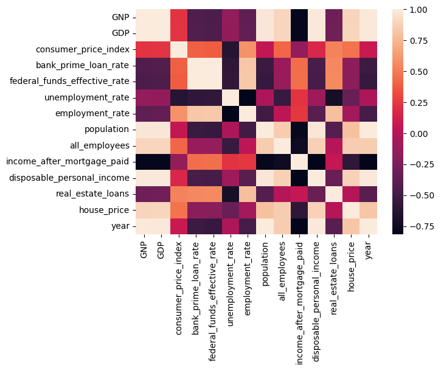

```python
sns.heatmap(df1.corr())
```

```python
df1.corr()['house_price']
```

```
GNP                             0.890373
GDP                             0.895864
consumer_price_index            0.464338
bank_prime_loan_rate           -0.170432
federal_funds_effective_rate   -0.184653
unemployment_rate              -0.326860
employment_rate                -0.075206
population                      0.800244
all_employees                   0.853787
income_after_mortgage_paid     -0.589658
disposable_personal_income      0.874097
real_estate_loans              -0.008983
house_price                     1.000000
year                            0.819425
Name: house_price, dtype: float64
```

```python
print(round(df1.corr()['house_price']*100),2)
```

```
GNP                              89.0
GDP                              90.0
consumer_price_index             46.0
bank_prime_loan_rate            -17.0
federal_funds_effective_rate    -18.0
unemployment_rate               -33.0
employment_rate                  -8.0
population                       80.0
all_employees                    85.0
income_after_mortgage_paid      -59.0
disposable_personal_income       87.0
real_estate_loans                -1.0
house_price                     100.0
year                             82.0
Name: house_price, dtype: float64 2
```

# Findings:

from the above correlation table we can see that house prices are in a very strong positive correlation with GNP, GDP, Population, No. of Working employees, and disposable personal income. This shows us that when there is a rise in these factors in the economy this raises the house prices.

There's a loose negative correlation of house prices with Unemployment Rate, Income after mortgage paid and federal funds effective rate, this shows us that when there's a rise in economy of these factors, it affects the price negatively hence making the prices go down of houses.

```python
df1.head()
```

|  | date | GNP | GDP | consumer_price_index | bank_prime_loan_rate | federal_funds_effective_rate | unemployment_rate | employment_rate | population | all_employees | income_after_mortgage_paid | disposable_personal_income | real_estate_loans | house_price | year |
| --- | --- | --- | --- | --- | --- | --- | --- | --- | --- | --- | --- | --- | --- | --- | --- |
| 0 | 2000-01-01 | 10289.43 | 10250.95 | 2.69 | 9.24 | 6.24 | 3.97 | 74.09 | 212576.75 | 132018.33 | 5.64 | 7419.58 | 11.61 | 104.77 | 2000 |
| 1 | 2001-01-01 | 10632.29 | 10581.93 | 3.23 | 6.94 | 3.88 | 4.74 | 73.11 | 215092.50 | 132078.25 | 5.79 | 7773.76 | 7.06 | 113.18 | 2001 |
| 2 | 2002-01-01 | 10974.90 | 10929.11 | 3.24 | 4.68 | 1.67 | 5.78 | 71.92 | 217569.58 | 130634.58 | 5.81 | 8108.77 | 13.73 | 122.28 | 2002 |
| 3 | 2003-01-01 | 11514.95 | 11456.45 | 2.33 | 4.12 | 1.13 | 5.99 | 71.21 | 221167.92 | 130327.00 | 5.83 | 8494.98 | 9.55 | 133.73 | 2003 |
| 4 | 2004-01-01 | 12293.91 | 12217.20 | 2.22 | 4.34 | 1.35 | 5.54 | 71.21 | 223356.83 | 131755.08 | 5.90 | 8995.52 | 13.46 | 150.44 | 2004 |

```python
factor = ['date', 'GNP', 'GDP', 'consumer_price_index', 'bank_prime_loan_rate',
       'federal_funds_effective_rate', 'unemployment_rate', 'employment_rate',
       'population', 'all_employees', 'income_after_mortgage_paid',
       'disposable_personal_income', 'real_estate_loans', 'house_price',
       'year']
```

```python
sns.pairplot(df1, y_vars= ['house_price'], x_vars= factor, height=3,aspect=2 )
```

[figure not shown]

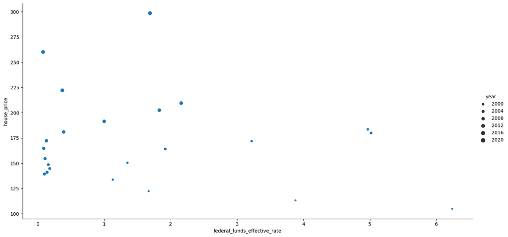

```python
sns.relplot(x='federal_funds_effective_rate',y='house_price',data=df1,size='year',height=7,aspect=2)
```

```python
df1.head()
```

|  | date | GNP | GDP | consumer_price_index | bank_prime_loan_rate | federal_funds_effective_rate | unemployment_rate | employment_rate | population | all_employees | income_after_mortgage_paid | disposable_personal_income | real_estate_loans | house_price | year |
| --- | --- | --- | --- | --- | --- | --- | --- | --- | --- | --- | --- | --- | --- | --- | --- |
| 0 | 2000-01-01 | 10289.43 | 10250.95 | 2.69 | 9.24 | 6.24 | 3.97 | 74.09 | 212576.75 | 132018.33 | 5.64 | 7419.58 | 11.61 | 104.77 | 2000 |
| 1 | 2001-01-01 | 10632.29 | 10581.93 | 3.23 | 6.94 | 3.88 | 4.74 | 73.11 | 215092.50 | 132078.25 | 5.79 | 7773.76 | 7.06 | 113.18 | 2001 |
| 2 | 2002-01-01 | 10974.90 | 10929.11 | 3.24 | 4.68 | 1.67 | 5.78 | 71.92 | 217569.58 | 130634.58 | 5.81 | 8108.77 | 13.73 | 122.28 | 2002 |
| 3 | 2003-01-01 | 11514.95 | 11456.45 | 2.33 | 4.12 | 1.13 | 5.99 | 71.21 | 221167.92 | 130327.00 | 5.83 | 8494.98 | 9.55 | 133.73 | 2003 |
| 4 | 2004-01-01 | 12293.91 | 12217.20 | 2.22 | 4.34 | 1.35 | 5.54 | 71.21 | 223356.83 | 131755.08 | 5.90 | 8995.52 | 13.46 | 150.44 | 2004 |

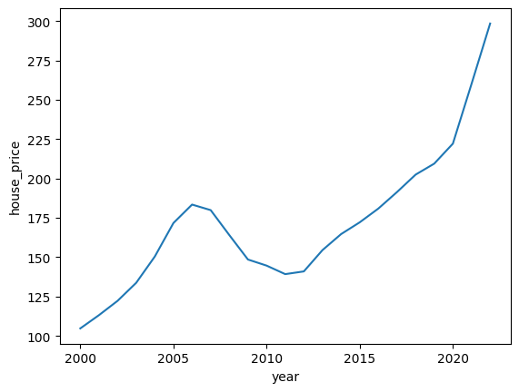

```python
sns.lineplot(data = df1, x = 'year', y = 'house_price')
```

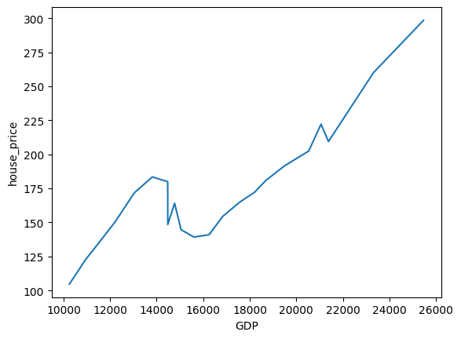

```python
sns.lineplot(data = df1, x = 'GDP', y = 'house_price')
```

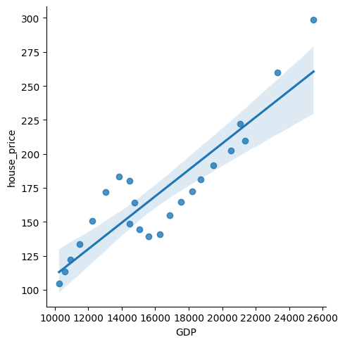

```python
sns.lmplot(x='GDP',y= 'house_price', data=df1)
```

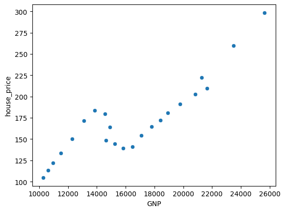

```python
sns.scatterplot(data= df1, x = 'GNP', y= 'house_price')
```

GNP has also same kind of relationship just like the GDP

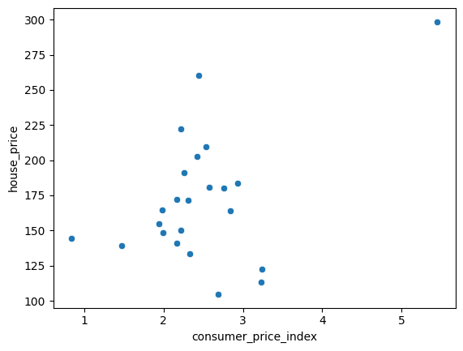

```python
sns.scatterplot(df1, x= 'consumer_price_index', y = 'house_price')
```

There's no relation or a very loose relationship between House price and consumer price index

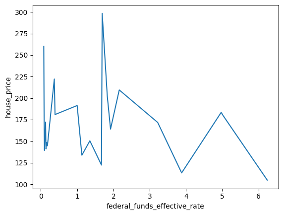

```python
sns.lineplot(data= df1, x = 'federal_funds_effective_rate', y= 'house_price')
```

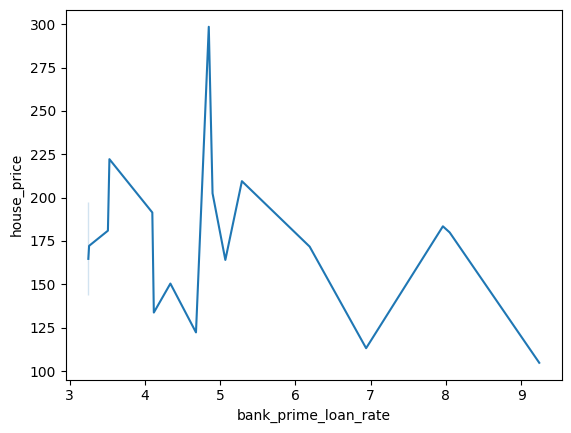

```python
sns.lineplot(data= df1, x = 'bank_prime_loan_rate', y= 'house_price')
```

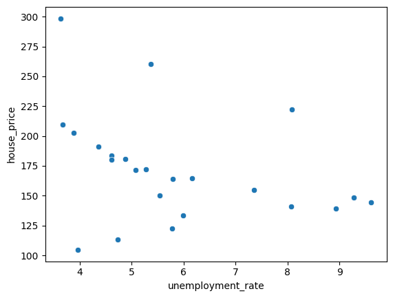

```python
sns.scatterplot(data= df1, x = 'unemployment_rate', y= 'house_price')
```

From the above graph we can observe that there's a loose negative correlation between unemployment rate and house price. Which means that increase in unemployment rate impacts the house prices negatively.

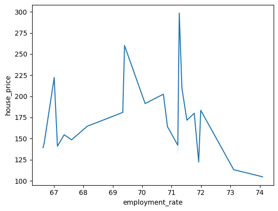

```python
sns.lineplot(data= df1, x = 'employment_rate', y= 'house_price')
```

we are not able to conclude any relationship between employment rate and house price due to defects in data.

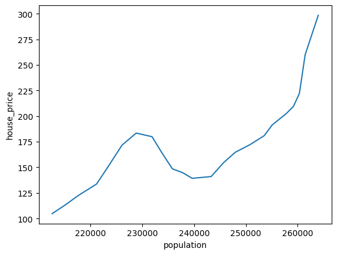

```python
sns.lineplot(data= df1, x = 'population', y= 'house_price')
```

There's a positive correlation between House Prices and population, as the population increases the prices of the houses also increase

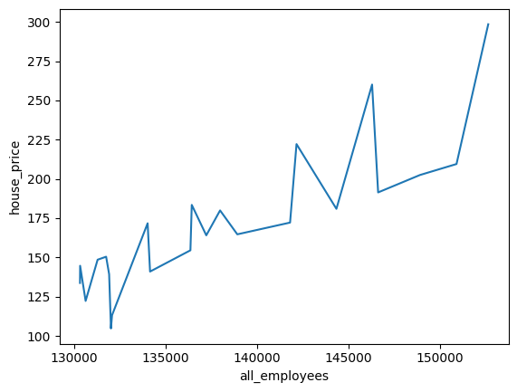

```python
sns.lineplot(data= df1, x = 'all_employees', y= 'house_price')
```

We can see that as with the increase in the rise in employee i.e., the working population the house price also increase hence showing a very close to positive relationship between both the variables.

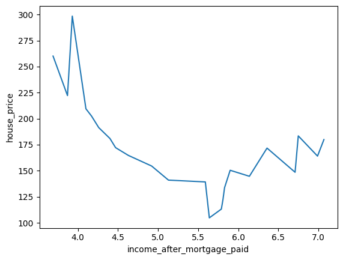

```python
sns.lineplot(data= df1, x = 'income_after_mortgage_paid', y= 'house_price')
```

There's a negative correlation between the two

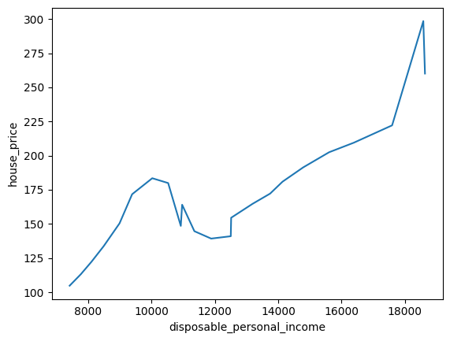

```python
sns.lineplot(data= df1, x = 'disposable_personal_income', y= 'house_price')
```

From the above chart we can observe that when the disposable income of the people increase, there's a demand of houses thereby making the prices rise hence showing a positive Correlation. there's a dip in the graph which accounts to the 2008 Financial Crisis.

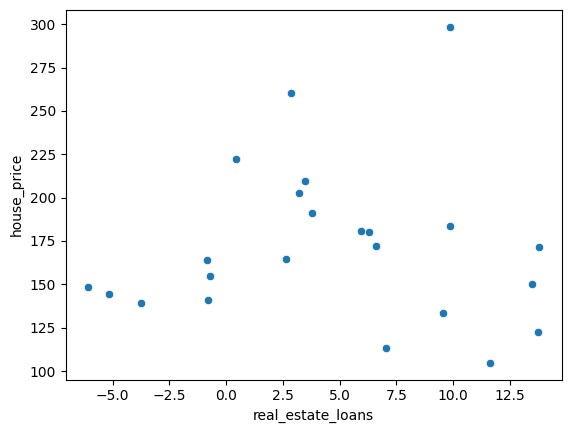

```python
sns.scatterplot(data= df1, x = 'real_estate_loans', y= 'house_price')
```

There's no feasible realtionship between the two.

```python
df1.corr()['house_price']
```

```
GNP                             0.890373
GDP                             0.895864
consumer_price_index            0.464338
bank_prime_loan_rate           -0.170432
federal_funds_effective_rate   -0.184653
unemployment_rate              -0.326860
employment_rate                -0.075206
population                      0.800244
all_employees                   0.853787
income_after_mortgage_paid     -0.589658
disposable_personal_income      0.874097
real_estate_loans              -0.008983
house_price                     1.000000
year                            0.819425
Name: house_price, dtype: float64
```

```python
print('The Correlation percentage of the variables with House Price. \nHigher the positive Value that means Positive Correlation and Vice-Versa\n')
print(round(df1.corr()['house_price']*100),2)
```

```
The Correlation percentage of the variables with House Price.
Higher the positive Value that means Positive Correlation and Vice-Versa

GNP                              89.0
GDP                              90.0
consumer_price_index             46.0
bank_prime_loan_rate            -17.0
federal_funds_effective_rate    -18.0
unemployment_rate               -33.0
employment_rate                  -8.0
population                       80.0
all_employees                    85.0
income_after_mortgage_paid      -59.0
disposable_personal_income       87.0
real_estate_loans                -1.0
house_price                     100.0
year                             82.0
Name: house_price, dtype: float64 2
```

# Model Training

```python
modl = df1.copy()
```

```python
modl.head()
```

|  | date | GNP | GDP | consumer_price_index | bank_prime_loan_rate | federal_funds_effective_rate | unemployment_rate | employment_rate | population | all_employees | income_after_mortgage_paid | disposable_personal_income | real_estate_loans | house_price | year |
| --- | --- | --- | --- | --- | --- | --- | --- | --- | --- | --- | --- | --- | --- | --- | --- |
| 0 | 2000-01-01 | 10289.43 | 10250.95 | 2.69 | 9.24 | 6.24 | 3.97 | 74.09 | 212576.75 | 132018.33 | 5.64 | 7419.58 | 11.61 | 104.77 | 2000 |
| 1 | 2001-01-01 | 10632.29 | 10581.93 | 3.23 | 6.94 | 3.88 | 4.74 | 73.11 | 215092.50 | 132078.25 | 5.79 | 7773.76 | 7.06 | 113.18 | 2001 |
| 2 | 2002-01-01 | 10974.90 | 10929.11 | 3.24 | 4.68 | 1.67 | 5.78 | 71.92 | 217569.58 | 130634.58 | 5.81 | 8108.77 | 13.73 | 122.28 | 2002 |
| 3 | 2003-01-01 | 11514.95 | 11456.45 | 2.33 | 4.12 | 1.13 | 5.99 | 71.21 | 221167.92 | 130327.00 | 5.83 | 8494.98 | 9.55 | 133.73 | 2003 |
| 4 | 2004-01-01 | 12293.91 | 12217.20 | 2.22 | 4.34 | 1.35 | 5.54 | 71.21 | 223356.83 | 131755.08 | 5.90 | 8995.52 | 13.46 | 150.44 | 2004 |

```python
modl.columns
```

```
Index(['date', 'GNP', 'GDP', 'consumer_price_index', 'bank_prime_loan_rate',
       'federal_funds_effective_rate', 'unemployment_rate', 'employment_rate',
       'population', 'all_employees', 'income_after_mortgage_paid',
       'disposable_personal_income', 'real_estate_loans', 'house_price',
       'year'],
      dtype='object')
```

```python
X = modl[['GNP', 'GDP', 'consumer_price_index', 'bank_prime_loan_rate',
       'federal_funds_effective_rate', 'unemployment_rate', 'employment_rate',
       'population', 'all_employees', 'income_after_mortgage_paid',
       'disposable_personal_income', 'real_estate_loans',]]
y = modl['house_price']
```

```python
X
```

|  | GNP | GDP | consumer_price_index | bank_prime_loan_rate | federal_funds_effective_rate | unemployment_rate | employment_rate | population | all_employees | income_after_mortgage_paid | disposable_personal_income | real_estate_loans |
| --- | --- | --- | --- | --- | --- | --- | --- | --- | --- | --- | --- | --- |
| 0 | 10289.43 | 10250.95 | 2.69 | 9.24 | 6.24 | 3.97 | 74.09 | 212576.75 | 132018.33 | 5.64 | 7419.58 | 11.61 |
| 1 | 10632.29 | 10581.93 | 3.23 | 6.94 | 3.88 | 4.74 | 73.11 | 215092.50 | 132078.25 | 5.79 | 7773.76 | 7.06 |
| 2 | 10974.90 | 10929.11 | 3.24 | 4.68 | 1.67 | 5.78 | 71.92 | 217569.58 | 130634.58 | 5.81 | 8108.77 | 13.73 |
| 3 | 11514.95 | 11456.45 | 2.33 | 4.12 | 1.13 | 5.99 | 71.21 | 221167.92 | 130327.00 | 5.83 | 8494.98 | 9.55 |
| 4 | 12293.91 | 12217.20 | 2.22 | 4.34 | 1.35 | 5.54 | 71.21 | 223356.83 | 131755.08 | 5.90 | 8995.52 | 13.46 |
| 5 | 13114.00 | 13039.20 | 2.31 | 6.19 | 3.22 | 5.08 | 71.52 | 226082.58 | 134021.33 | 6.36 | 9392.46 | 13.79 |
| 6 | 13862.04 | 13815.58 | 2.93 | 7.96 | 4.97 | 4.61 | 71.99 | 228814.67 | 136432.17 | 6.75 | 10027.72 | 9.88 |
| 7 | 14569.89 | 14474.23 | 2.76 | 8.05 | 5.02 | 4.62 | 71.77 | 231867.00 | 137978.75 | 7.07 | 10528.88 | 6.31 |
| 8 | 14915.08 | 14769.86 | 2.84 | 5.07 | 1.92 | 5.80 | 70.86 | 233788.00 | 137224.92 | 6.99 | 10970.07 | -0.85 |
| 9 | 14628.31 | 14478.07 | 1.99 | 3.25 | 0.16 | 9.28 | 67.60 | 235801.00 | 131290.00 | 6.71 | 10928.03 | -6.07 |
| 10 | 15254.60 | 15048.97 | 0.84 | 3.25 | 0.18 | 9.61 | 66.67 | 237829.33 | 130334.58 | 6.14 | 11356.88 | -5.18 |
| 11 | 15837.66 | 15599.73 | 1.47 | 3.25 | 0.10 | 8.93 | 66.63 | 239617.50 | 131919.50 | 5.59 | 11885.60 | -3.74 |
| 12 | 16486.73 | 16253.97 | 2.17 | 3.25 | 0.14 | 8.07 | 67.12 | 243284.33 | 134154.33 | 5.13 | 12504.83 | -0.82 |
| 13 | 17073.49 | 16843.20 | 1.94 | 3.25 | 0.11 | 7.36 | 67.35 | 245679.33 | 136358.33 | 4.92 | 12517.27 | -0.72 |
| 14 | 17785.91 | 17550.69 | 1.98 | 3.25 | 0.09 | 6.16 | 68.14 | 247946.58 | 138919.50 | 4.63 | 13191.99 | 2.63 |
| 15 | 18426.41 | 18206.02 | 2.17 | 3.26 | 0.13 | 5.28 | 68.70 | 250800.58 | 141801.17 | 4.47 | 13745.28 | 6.58 |
| 16 | 18927.05 | 18695.11 | 2.57 | 3.51 | 0.39 | 4.88 | 69.34 | 253537.50 | 144332.42 | 4.40 | 14138.67 | 5.94 |
| 17 | 19770.29 | 19477.34 | 2.26 | 4.10 | 1.00 | 4.36 | 70.10 | 255079.00 | 146610.92 | 4.26 | 14791.22 | 3.78 |
| 18 | 20823.36 | 20533.06 | 2.42 | 4.90 | 1.83 | 3.89 | 70.72 | 257790.67 | 148897.00 | 4.17 | 15608.88 | 3.22 |
| 19 | 21659.03 | 21380.98 | 2.53 | 5.29 | 2.16 | 3.68 | 71.35 | 259175.00 | 150891.42 | 4.10 | 16388.58 | 3.46 |
| 20 | 21257.44 | 21060.47 | 2.22 | 3.53 | 0.37 | 8.09 | 67.01 | 260329.00 | 142153.17 | 3.87 | 17595.93 | 0.42 |
| 21 | 23488.17 | 23315.08 | 2.44 | 3.25 | 0.08 | 5.37 | 69.40 | 261445.17 | 146280.92 | 3.69 | 18633.12 | 2.85 |
| 22 | 25640.13 | 25462.72 | 5.45 | 4.85 | 1.69 | 3.64 | 71.26 | 263973.50 | 152625.25 | 3.93 | 18580.57 | 9.88 |

```python
y
```

```
0     104.77
1     113.18
2     122.28
3     133.73
4     150.44
5     171.74
6     183.45
7     179.92
8     164.06
9     148.54
10    144.67
11    139.26
12    140.99
13    154.52
14    164.70
15    172.18
16    180.93
17    191.40
18    202.48
19    209.47
20    222.16
21    260.07
22    298.48
Name: house_price, dtype: float64
```

```python
from sklearn.model_selection import train_test_split
X_train,X_test,y_train,y_test=train_test_split(X,y,test_size=0.2)
```

```python
from sklearn.linear_model import LinearRegression
```

```python
from sklearn.metrics import r2_score
```

```python
lr=LinearRegression()
```

```python
lr.fit(X_train, y_train)
```

```
LinearRegression()
```

```python
lr.predict(X_test)
```

```
array([167.62267014, 116.43290737, 183.74393047, 137.04631946,
       132.5162308 ])
```

```python
lr.score(X_test, y_test)
```

```
0.9350570032225217
```

```python
y_test
```

```
5     171.74
0     104.77
16    180.93
11    139.26
2     122.28
Name: house_price, dtype: float64
```

```python
r2 = round(r2_score(y_test, lr.predict(X_test)),2)
print(f'The accuracy of our model is {r2*100}%')
```

```
The accuracy of our model is 94.0%
```